# A Data Story about ANES in 2016

Shuyuan Wang, sw3449

9/22/2020

# 1. Introduction

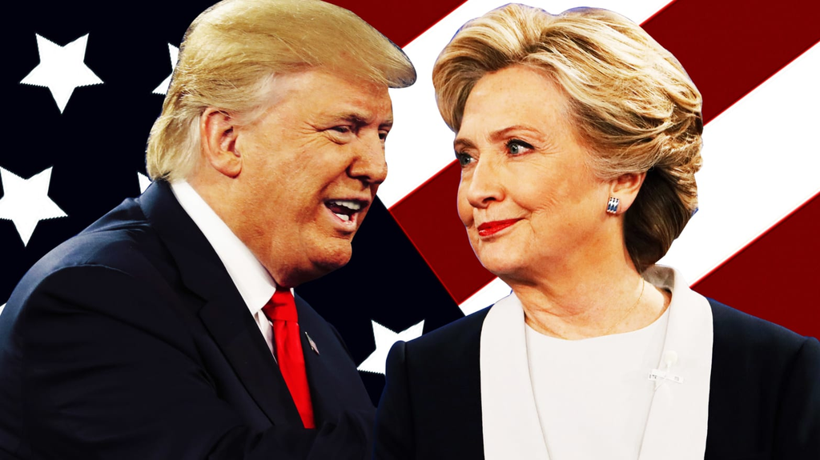

Source: https://www.thedailybeast.com/donald-trump-goes-full-rage-monster-on-hillary-and-bill-clinton

In the remaining several months of 2020, the U.S. president election will be catching everyone’s eyes. Voters in America will decide on 3 November whether Donald Trump remains in the White House for another four years. Speaking of President Trump, his victory over Hillary Clinton in the 2016 presidential election stunned many political observers and pollsters who expected Hillary to be the winner. In this blog, I would like to look deeper into the supporters for these two president candidates using the ANES 2016 Time Series data.

Before diving into details, let me summarize the questions I want to answer with the data:

1. What were different candidates’ supporters’ opinion on Obama, the previous president?
   - More specifically, what were their affect direction and their feeling thermometer values?
2. How many interviewers voted for Hillary and Trump?
   - Where did they locate?
   - Was the survey data consistent with the actual result?

# 2. Basic information of the dataset

The 2016 ANES Time Series Study contains 4270 cross-sectional cases. Pre-election interviews were conducted with study respondents during the two months prior to the 2016 elections and were followed by post-election interviewing beginning November 9, 2016. There were two modes of the study, face-to-face interviewing was complemented with data collection on the Internet, using substantially identical questionnaires.

Among thousands of variables contained in the dataset, I select some of them for the analysis. The variables selected are, for example, 2016 presidential vote, state code, feeling thermometer and affect for Barack Obama, opinion on gay marriage.

# 3. Analysis

## 3.1 What was voters’ opinion on Barack Obama？

### 3.1.1 What was voters’ affect for Obama?

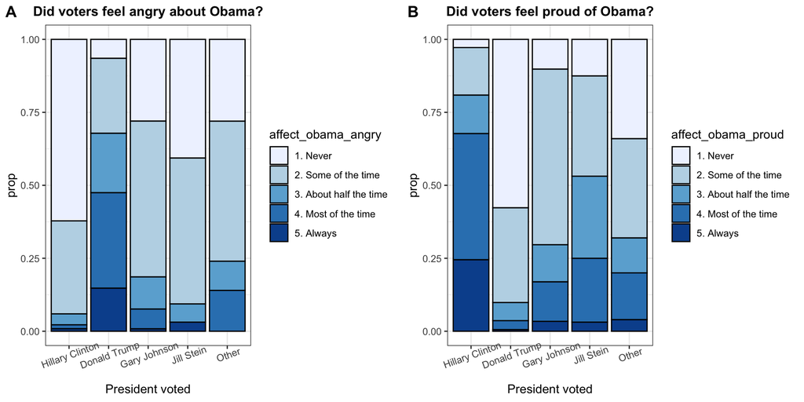

### 3.1.2 What were voters’ feeling thermometer values for Obama?

Next, let’s see how did voters feel about Obama.

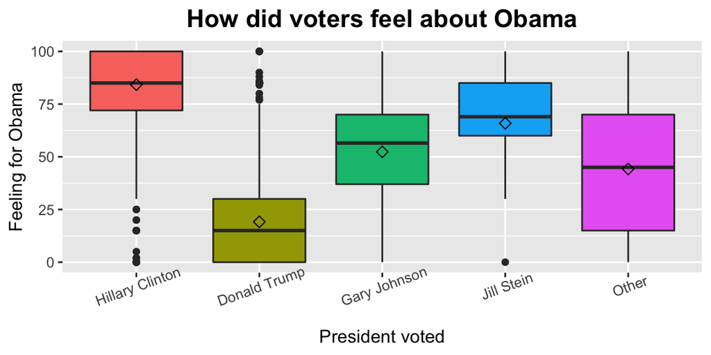

Well, it’s not surprisng to see the average feeling thermometer value for Obama in the first two groups were around 85 and 20 respectively, given the fact that most voters showed negative affact for Obama if they supported Donald Trump, and showed positive affect for Obama if they supported Hillary Clinton. However, one thing catches my attention. The feeling thermometer values for Obama in the first two groups were quite spread out. There were many outliers (exceeding $Q1-1.5*IQR$ or $Q3+1.5*IQR$) in the first two groups.

Let’s separate the two modes of interviewers to see the feeling thermometer values.

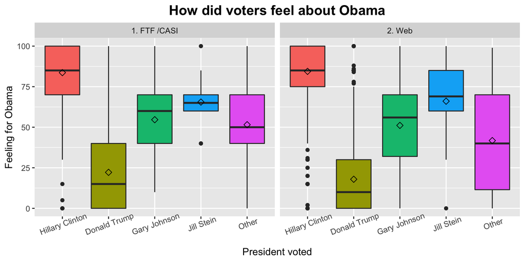

The pattern still holds. However, for Donald Trump voter group, more outliers in Web interview group than Face-to-Face group. It might be due to the fact that when doing questionnaire online, people lost patience and just entered number randomly. But fairly speaking, the wide-spread feeling thermometer values for Obama were actually reasonable. On one hand, he did bring the changes. The U.S. economy revives from aftermath of the Great Recession in his presidency; He expands Medicaid to uninsured low-income Americans. On the other hand, he didn’t relieve the racial tensions.

## 3.2 Who did interviewers vote for in 2016 election?

According to the post-election interview, we can summarize who did the voters vote in the 2016 election.

### 3.2.1 Who was voted more, Hillary Clinton or Donald Trump?

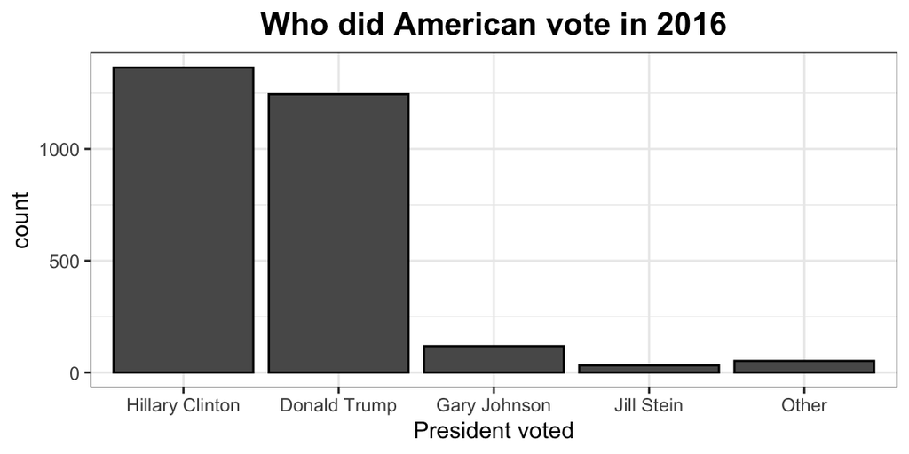

The histogram tells us that Hillary Clinton won more votes than Donald Trump.

### 3.2.2 Was the survey data consistent with the actual result?

It is known to all that the election of the president is an indirect election, in which citizens of the U.S. who are registered to vote in one of the 50 U.S. states or in Washingtong D.C., cast balllots not directly for those offices, but instead for members of the Electoral College. These electors then cast direct votes, known as electoral votes, for president.

Typically, state laws establish a winner-take-all system, wherein the ticket that wins a plurality of votes wins all of that state’s allocated electoral votes. Different states have different number of electoral votes due to the population difference.

So, where did those interviewees come from?

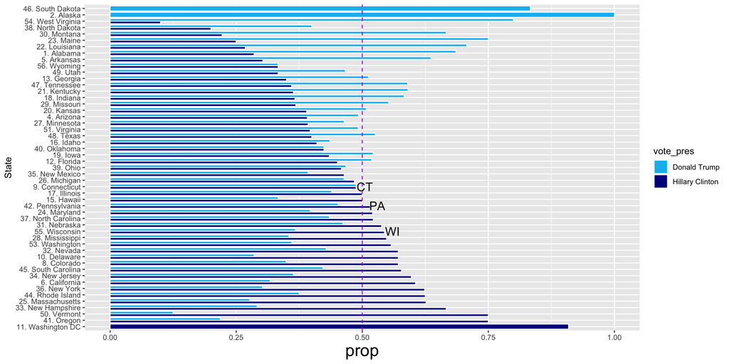

According to the barplot, we can see that in Wisconsin and Pennsylvania, Hillary won more votes than Trump, and had the same proportion of support as Trump in Connecticut.

However, in the 2016 Electoral College map (the actual result), we can see that Hillary didn’t get the electoral votes in Wisconsin and Pennsylvania, but did get the electoral votes in Connecticut.

[figure not shown]

2016 ElectoralCollegeMap. Source: https://commons.wikimedia.org/wiki/File:ElectoralCollege2016.svg

Well, that is the discrepancy between survey sample and the reality. We should be aware of the error coming from sample. The error might be due to response or non-response biases. For example, by looking at the number of respondents from each state, we notice that there was only one respondent from Alaska, which would definitely cause bias. Apart from the number of samples in the survey, how the samples are consituted are also important. For example, in order to have representative samples, one should consider stratified sampling method.

| state | n |
| --- | --- |
| 2. Alaska | 1 |
| 56. Wyoming | 3 |
| 38. North Dakota | 5 |
| 15. Hawaii | 6 |
| 46. South Dakota | 6 |
| 10. Delaware | 7 |

#### Other limitation of the survey data?

For the topic like opinion towards gay marriage, it’s not surprising that people who voted for Donald Trump were not proponent of gay marriage. However, the proportion of the opinion “There should be no legal recognition of a gay or lesbian couple’s relationship” is higher in the Web group than the Face-to-Face group. It might be due to the fact that people are shy if interviewed by another person and may give the answer that is modified.

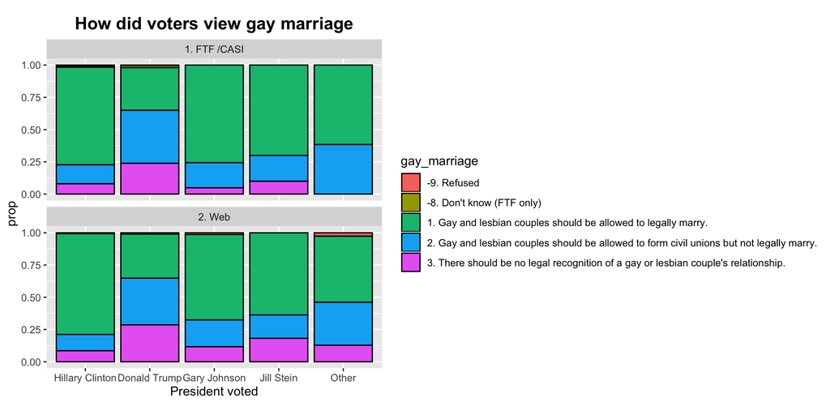

# 4. Summary

By looking back at the 2016 election survey data, we discover that interviewees who voted for Hillary Clinton showed positive attitude towards Barack Obama, and the interviewees who supported Donald Trump had quite the opposite attitude. Moreover, the survey data statistics with regard to state-wise voting proportion is not consistent with the fact, which reminds us of the limitation of survey data. Survey is useful for us to know what is happening and how people are thinking. However, we should be careful when analyzing or drawing conclusion of the survey data due to response or non-response biases.

# 5. Reference

https://www.thedailybeast.com/donald-trump-goes-full-rage-monster-on-hillary-and-bill-clinton

https://en.wikipedia.org/wiki/United_States_presidential_election

https://commons.wikimedia.org/wiki/File:ElectoralCollege2016.svg

https://www.washingtonpost.com/lifestyle/kidspost/donald-trump-is-elected-president-of-the-united-states/2016/11/09/58046db4-a684-11e6-ba59-a7d93165c6d4_story.html